# Análisis cámaras 1-4

March - July 2019

### Treatments

| Camara | Fotoperiodo | Temperatura |
| --- | --- | --- |
| Camara1 | 16/8h | 18/16ºC |
| Camara2 | 8/16h | 18/16ºC |
| Camara3 | 16/8h | 25/22ºC |
| Camara4 | 8/16h | 25/22ºC |

### Dependencies

```r
library(readr)
library(dplyr)
library(ggplot2)
library(forcats)
```

### Load functions

```r
source("functions.R")
```

### Load data

```r
cams = read_csv("data/cams_wo_outliers.csv")
```

### Sample distribution

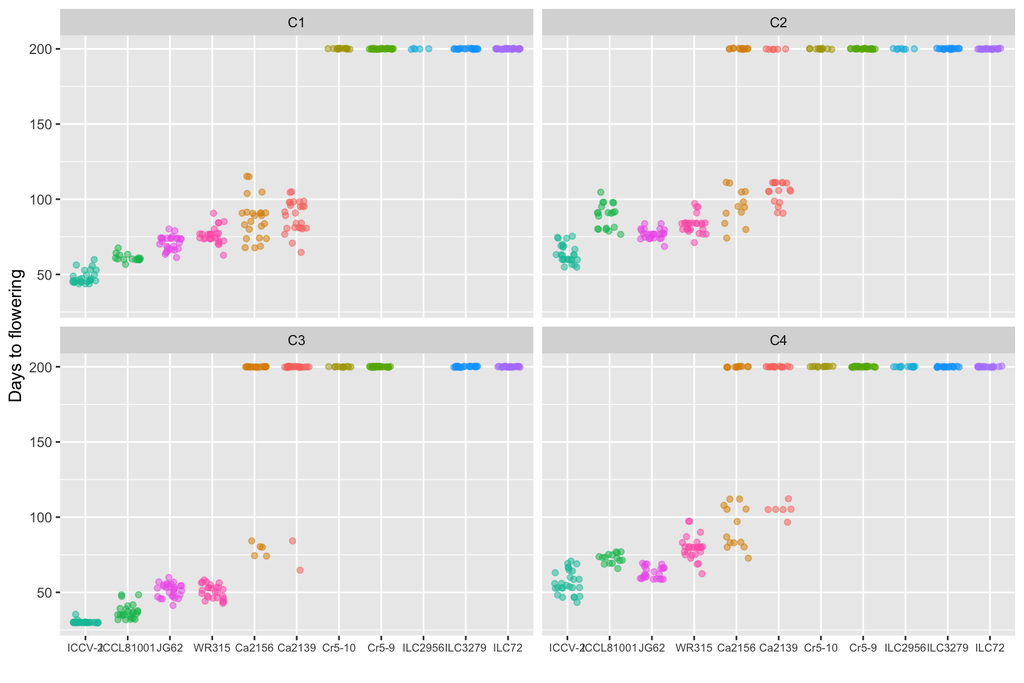

```r
mi_treat = "non-vern"

set.seed(123)

cams %>%
  filter(Treatment == mi_treat, !is.na(DFAbierta)) %>%
  ggplot(aes(fct_reorder(Genotype, DFAbierta), DFAbierta,
             col = Genotype)) +
  geom_jitter(alpha = 0.5, width = 0.3) +
  facet_wrap(~Camara) +
  labs(x = "", y = "Days to flowering") +
  theme(legend.position = "none", axis.text.x = element_text(size=7))
```

### Caso Study 1

Media 3 macetas por repetición :

- Genotipo
- Cámara
- Repetición
- n, número plantas en la rep.
- avg, media de esas plantas (días)
- sd, desv standard del valor medio
- Flor1, primera flor en la rep. (días)

```
## # A tibble: 128 x 7
##    Genotype Camara Repetition     n   avg    sd Flor1
##    <chr>    <chr>  <chr>      <int> <dbl> <dbl> <dbl>
##  1 Ca2139   C1     Rep1           8  79.8  9.51    65
##  2 Ca2139   C1     Rep2           9  90.7  8.43    77
##  3 Ca2139   C1     Rep3           8  95.8  6.82    81
##  4 Ca2139   C2     Rep1           9 102.   7.92    91
##  5 Ca2139   C2     Rep2           8 129.  43.9     98
##  6 Ca2139   C2     Rep3           6 170.  46.0    111
##  7 Ca2139   C3     Rep1           7 200    0      200
##  8 Ca2139   C3     Rep2           8 186.  41.0     84
##  9 Ca2139   C3     Rep3           9 185   45       65
## 10 Ca2139   C4     Rep1           7 131   47.2     97
## # … with 118 more rows
```

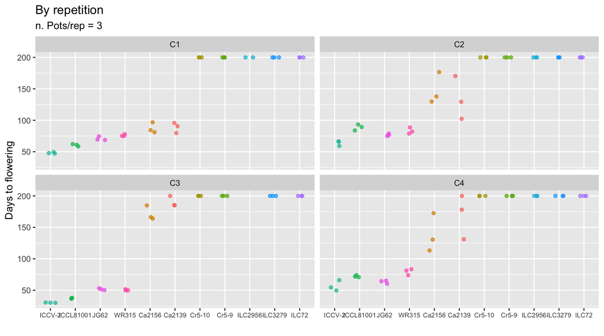

**Normality test**

Salvo una de las colas, la variable parece distribuirse de forma normal en cada uno de los grupos :

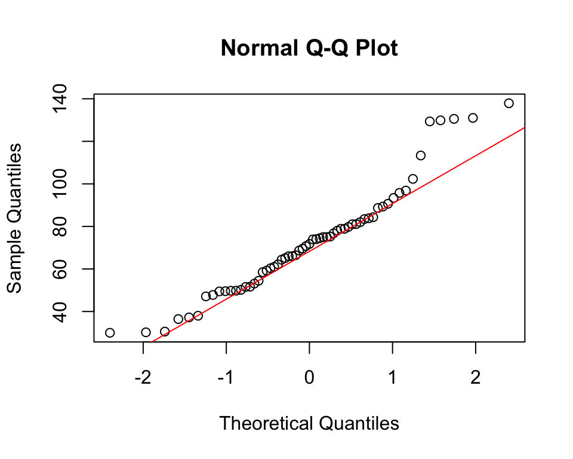

**ANOVA**  
Diferencias entre genotipos para las 4 cámaras :

```r
by(data = by_reps,
   INDICES = by_reps$Camara,
   FUN = function(x){ summary(aov(x$avg ~ x$Genotype))})
```

```
##             Df Sum Sq Mean Sq F value    Pr(>F)
## x$Genotype  10 132817 13281.7  904.61 < 2.2e-16 ***
## Residuals   21    308    14.7
## ---
## Signif. codes:  0 '***' 0.001 '**' 0.01 '*' 0.05 '.' 0.1 ' ' 1
## --------------------------------------------------------
##             Df Sum Sq Mean Sq F value    Pr(>F)
## x$Genotype  10 100347 10034.7   59.13 1.511e-13 ***
## Residuals   22   3734   169.7
## ---
## Signif. codes:  0 '***' 0.001 '**' 0.01 '*' 0.05 '.' 0.1 ' ' 1
## --------------------------------------------------------
##             Df Sum Sq Mean Sq F value    Pr(>F)
## x$Genotype   9 167703 18633.7  889.93 < 2.2e-16 ***
## Residuals   20    419    20.9
## ---
## Signif. codes:  0 '***' 0.001 '**' 0.01 '*' 0.05 '.' 0.1 ' ' 1
## --------------------------------------------------------
##             Df Sum Sq Mean Sq F value    Pr(>F)
## x$Genotype  10 119499 11949.9   57.76 1.931e-13 ***
## Residuals   22   4552   206.9
## ---
## Signif. codes:  0 '***' 0.001 '**' 0.01 '*' 0.05 '.' 0.1 ' ' 1
```

**Comparaciones multiples Cámara 1**  
Todos las comparaciones entre pares son significativas (P adj) salvo :

```
##   Ca2156-Ca2139    Cr5-9-Cr5-10  ILC2956-Cr5-10  ILC3279-Cr5-10
##      0.99999639      1.00000000      1.00000000      1.00000000
##    ILC72-Cr5-10   ILC2956-Cr5-9   ILC3279-Cr5-9     ILC72-Cr5-9
##      1.00000000      1.00000000      1.00000000      1.00000000
##  JG62-ICCL81001 ILC3279-ILC2956   ILC72-ILC2956   ILC72-ILC3279
##      0.08944858      1.00000000      1.00000000      1.00000000
##      WR315-JG62
##      0.84016267
```

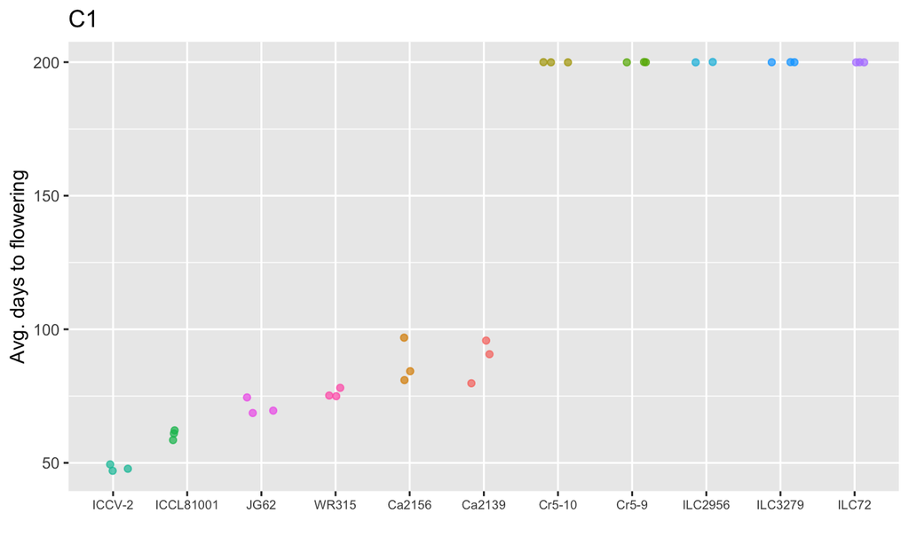

**Comparaciones multiples Cámara 2**  
Todos las comparaciones entre pares son significativas (P adj) salvo :

```
##    Ca2156-Ca2139     Cr5-9-Cr5-10   ILC2956-Cr5-10   ILC3279-Cr5-10
##        0.9533422        1.0000000        1.0000000        1.0000000
##     ILC72-Cr5-10    ILC2956-Cr5-9    ILC3279-Cr5-9      ILC72-Cr5-9
##        1.0000000        1.0000000        1.0000000        1.0000000
## ICCV-2-ICCL81001   JG62-ICCL81001  WR315-ICCL81001      JG62-ICCV-2
##        0.4395057        0.9845004        0.9999702        0.9727672
##     WR315-ICCV-2  ILC3279-ILC2956    ILC72-ILC2956    ILC72-ILC3279
##        0.7605037        1.0000000        1.0000000        1.0000000
##       WR315-JG62
##        0.9999202
```

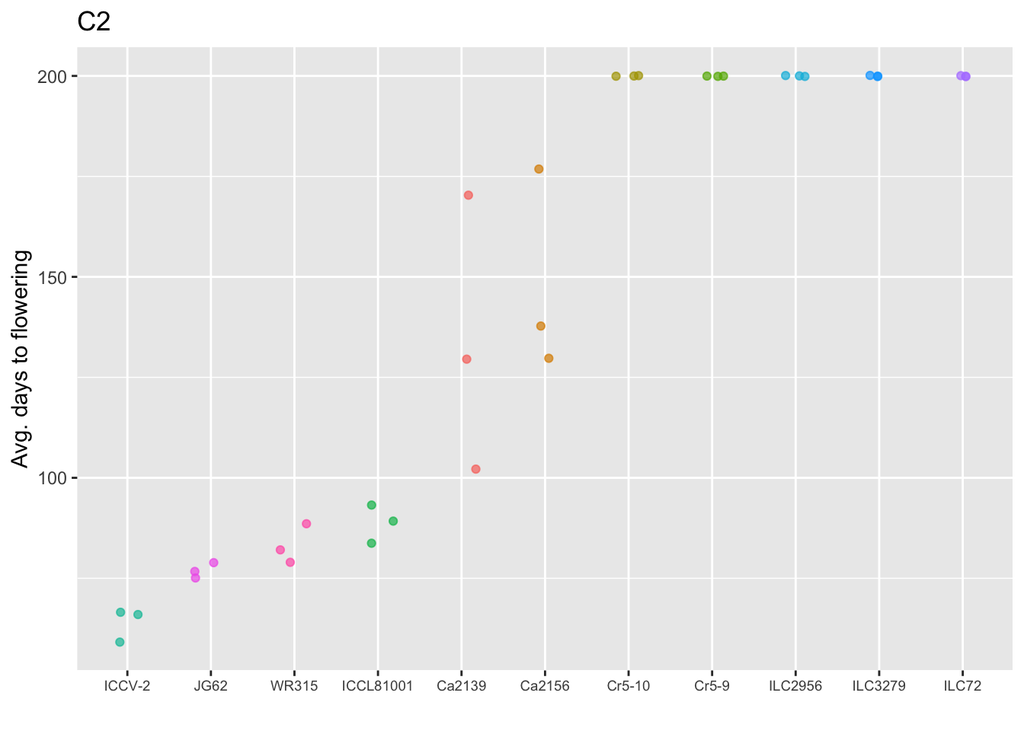

**Comparaciones multiples Cámara 3**  
Todos las comparaciones entre pares son significativas (P adj) salvo :

```
##    Cr5-10-Ca2139     Cr5-9-Ca2139   ILC3279-Ca2139     ILC72-Ca2139
##       0.26544526       0.26544526       0.26544526       0.26544526
##     Cr5-9-Cr5-10   ILC3279-Cr5-10     ILC72-Cr5-10    ILC3279-Cr5-9
##       1.00000000       1.00000000       1.00000000       1.00000000
##      ILC72-Cr5-9 ICCV-2-ICCL81001  WR315-ICCL81001    ILC72-ILC3279
##       1.00000000       0.69097729       0.05149149       1.00000000
##       WR315-JG62
##       0.99999862
```

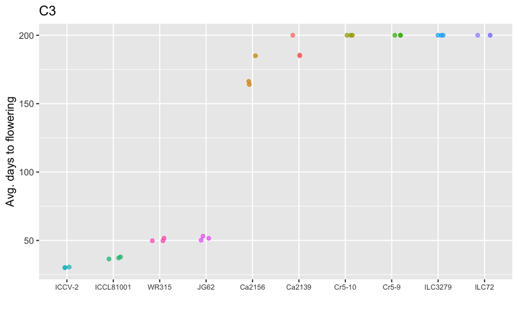

**Comparaciones multiples Cámara 4**  
Todos las comparaciones entre pares son significativas salvo :

```
##    Ca2156-Ca2139    Cr5-10-Ca2139     Cr5-9-Ca2139   ILC2956-Ca2139
##        0.2932101        0.3139290        0.3139290        0.3139290
##   ILC3279-Ca2139     ILC72-Ca2139     Cr5-9-Cr5-10   ILC2956-Cr5-10
##        0.3139290        0.3139290        1.0000000        1.0000000
##   ILC3279-Cr5-10     ILC72-Cr5-10    ILC2956-Cr5-9    ILC3279-Cr5-9
##        1.0000000        1.0000000        1.0000000        1.0000000
##      ILC72-Cr5-9 ICCV-2-ICCL81001   JG62-ICCL81001  WR315-ICCL81001
##        1.0000000        0.9550726        0.9993014        0.9998754
##      JG62-ICCV-2     WR315-ICCV-2  ILC3279-ILC2956    ILC72-ILC2956
##        0.9999514        0.6858081        1.0000000        1.0000000
##    ILC72-ILC3279       WR315-JG62
##        1.0000000        0.9406521
```

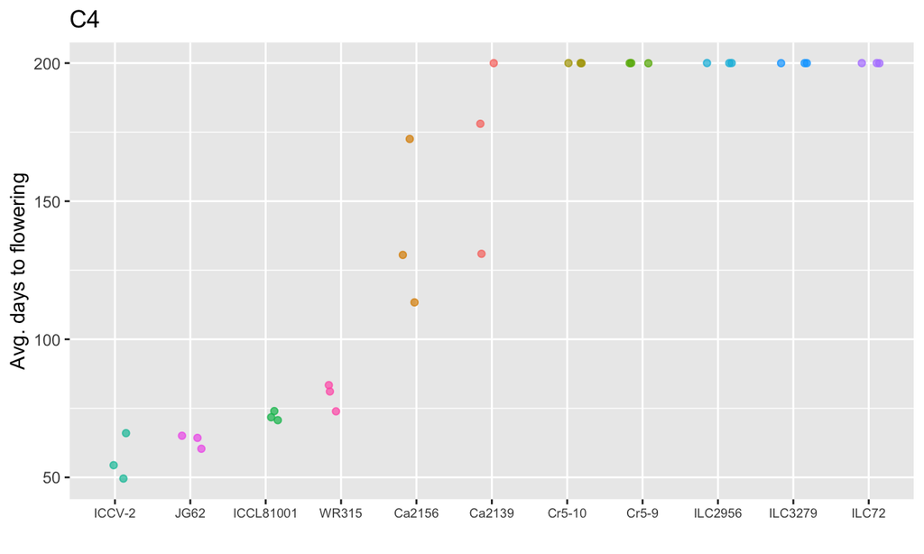

### Caso Study 2

Primera flor por repetición :

```r
by_reps %>% select(c(1:4,7))
```

```
## # A tibble: 128 x 5
##    Genotype Camara Repetition     n Flor1
##    <chr>    <chr>  <chr>      <int> <dbl>
##  1 Ca2139   C1     Rep1           8    65
##  2 Ca2139   C1     Rep2           9    77
##  3 Ca2139   C1     Rep3           8    81
##  4 Ca2139   C2     Rep1           9    91
##  5 Ca2139   C2     Rep2           8    98
##  6 Ca2139   C2     Rep3           6   111
##  7 Ca2139   C3     Rep1           7   200
##  8 Ca2139   C3     Rep2           8    84
##  9 Ca2139   C3     Rep3           9    65
## 10 Ca2139   C4     Rep1           7    97
## # … with 118 more rows
```

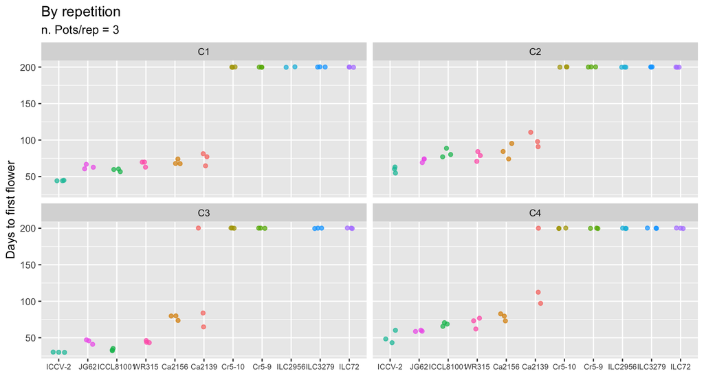

**Normality test**  
La variable parece distribuirse de forma normal :

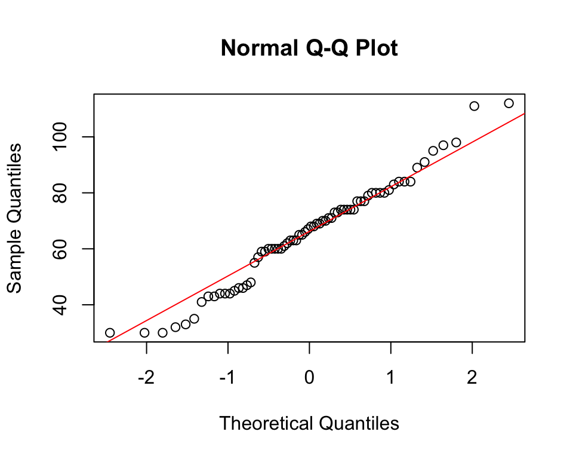

**ANOVA**  
Diferencias entre genotipos para las 4 cámaras :

```r
by(data = by_reps,
   INDICES = by_reps$Camara,
   FUN = function(x){ summary(aov(x$Flor1 ~ x$Genotype))})
```

```
##             Df Sum Sq Mean Sq F value    Pr(>F)
## x$Genotype  10 149138 14913.8  1419.3 < 2.2e-16 ***
## Residuals   21    221    10.5
## ---
## Signif. codes:  0 '***' 0.001 '**' 0.01 '*' 0.05 '.' 0.1 ' ' 1
## --------------------------------------------------------
##             Df Sum Sq Mean Sq F value    Pr(>F)
## x$Genotype  10 121861 12186.1   418.9 < 2.2e-16 ***
## Residuals   22    640    29.1
## ---
## Signif. codes:  0 '***' 0.001 '**' 0.01 '*' 0.05 '.' 0.1 ' ' 1
## --------------------------------------------------------
##             Df Sum Sq Mean Sq F value    Pr(>F)
## x$Genotype   9 162314 18034.9  33.601 3.768e-10 ***
## Residuals   20  10735   536.7
## ---
## Signif. codes:  0 '***' 0.001 '**' 0.01 '*' 0.05 '.' 0.1 ' ' 1
## --------------------------------------------------------
##             Df Sum Sq Mean Sq F value    Pr(>F)
## x$Genotype  10 137079 13707.9  46.169 1.984e-12 ***
## Residuals   22   6532   296.9
## ---
## Signif. codes:  0 '***' 0.001 '**' 0.01 '*' 0.05 '.' 0.1 ' ' 1
```

**Comparaciones multiples Cámara 1**  
Todos las comparaciones entre pares son significativas salvo :

```
##   Ca2156-Ca2139    WR315-Ca2139     JG62-Ca2156    WR315-Ca2156
##       0.8493390       0.3476408       0.4147237       0.9975164
##    Cr5-9-Cr5-10  ILC2956-Cr5-10  ILC3279-Cr5-10    ILC72-Cr5-10
##       1.0000000       1.0000000       1.0000000       1.0000000
##   ILC2956-Cr5-9   ILC3279-Cr5-9     ILC72-Cr5-9  JG62-ICCL81001
##       1.0000000       1.0000000       1.0000000       0.7876402
## WR315-ICCL81001 ILC3279-ILC2956   ILC72-ILC2956   ILC72-ILC3279
##       0.0945288       1.0000000       1.0000000       1.0000000
##      WR315-JG62
##       0.9001837
```

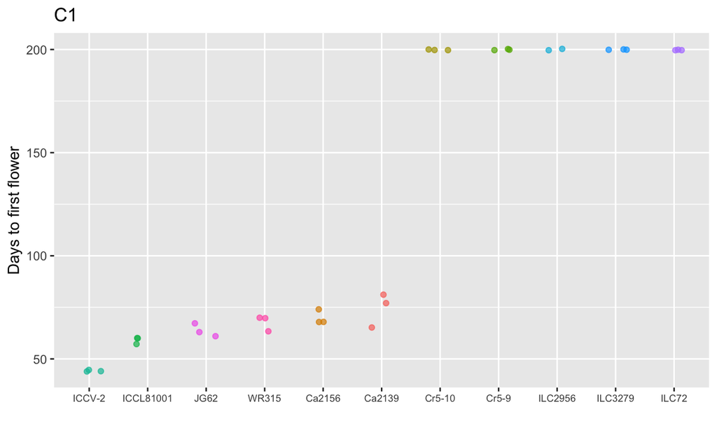

**Comparaciones multiples Cámara 2**  
Todos las comparaciones entre pares son significativas salvo :

```
##    Ca2156-Ca2139 ICCL81001-Ca2156      JG62-Ca2156     WR315-Ca2156
##        0.0518439        0.9999714        0.2506161        0.9248333
##     Cr5-9-Cr5-10   ILC2956-Cr5-10   ILC3279-Cr5-10     ILC72-Cr5-10
##        1.0000000        1.0000000        1.0000000        1.0000000
##    ILC2956-Cr5-9    ILC3279-Cr5-9      ILC72-Cr5-9   JG62-ICCL81001
##        1.0000000        1.0000000        1.0000000        0.5300473
##  WR315-ICCL81001      JG62-ICCV-2  ILC3279-ILC2956    ILC72-ILC2956
##        0.9969106        0.1695157        1.0000000        1.0000000
##    ILC72-ILC3279       WR315-JG62
##        1.0000000        0.9617198
```

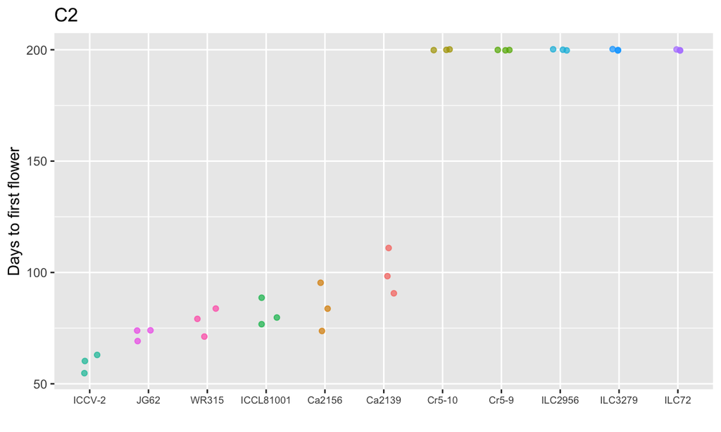

**Comparaciones multiples Cámara 3**  
Todos las comparaciones entre pares son significativas salvo :

```
##    Ca2156-Ca2139 ICCL81001-Ca2156    ICCV-2-Ca2156      JG62-Ca2156
##        0.5921738        0.3956898        0.3071426        0.7495564
##     WR315-Ca2156     Cr5-9-Cr5-10   ILC3279-Cr5-10     ILC72-Cr5-10
##        0.7396546        1.0000000        1.0000000        1.0000000
##    ILC3279-Cr5-9      ILC72-Cr5-9 ICCV-2-ICCL81001   JG62-ICCL81001
##        1.0000000        1.0000000        1.0000000        0.9997670
##  WR315-ICCL81001      JG62-ICCV-2     WR315-ICCV-2    ILC72-ILC3279
##        0.9998173        0.9982243        0.9985097        1.0000000
##       WR315-JG62
##        1.0000000
```

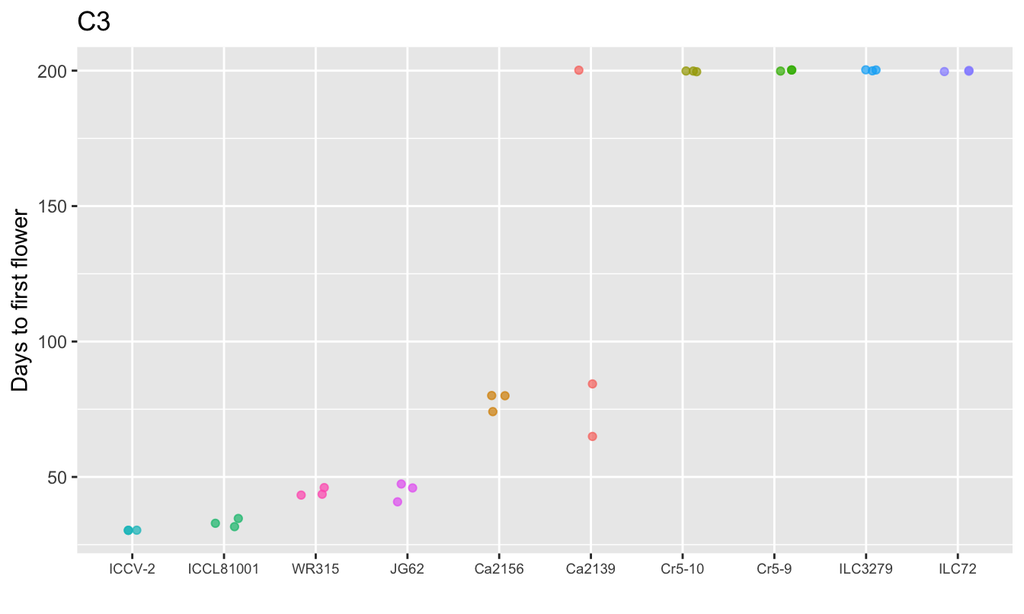

**Comparaciones multiples Cámara 4**  
Todos las comparaciones entre pares son significativas salvo :

```
## ICCL81001-Ca2156    ICCV-2-Ca2156      JG62-Ca2156     WR315-Ca2156
##        0.9996002        0.6423364        0.9424642        0.9999453
##     Cr5-9-Cr5-10   ILC2956-Cr5-10   ILC3279-Cr5-10     ILC72-Cr5-10
##        1.0000000        1.0000000        1.0000000        1.0000000
##    ILC2956-Cr5-9    ILC3279-Cr5-9      ILC72-Cr5-9 ICCV-2-ICCL81001
##        1.0000000        1.0000000        1.0000000        0.9585263
##   JG62-ICCL81001  WR315-ICCL81001      JG62-ICCV-2     WR315-ICCV-2
##        0.9997815        1.0000000        0.9998418        0.9226801
##  ILC3279-ILC2956    ILC72-ILC2956    ILC72-ILC3279       WR315-JG62
##        1.0000000        1.0000000        1.0000000        0.9988392
```

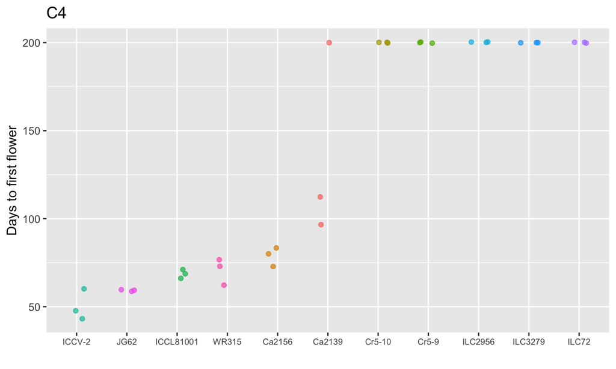